# practice2

Joseph Trembley

2/16/2022

```r
choco <- read.csv("https://ds202-at-isu.github.io/labs/data/choco.csv")
library(ggplot2)
```

github repo: https://github.com/trembleyjr/lab2

#Question Set I

Question 1: What is the overall number of chocolate bars rated?

```r
summary(choco)
```

```
##    Company          Specific.Bean.Origin      REF        Review.Date
##  Length:1852        Length:1852          Min.   :   5   Min.   :2006
##  Class :character   Class :character     1st Qu.: 600   1st Qu.:2010
##  Mode  :character   Mode  :character     Median :1099   Median :2013
##                                          Mean   :1065   Mean   :2012
##                                          3rd Qu.:1546   3rd Qu.:2015
##                                          Max.   :2008   Max.   :2017
##    Cocoa.Pct     Company.Location       Rating       Bean.Type
##  Min.   : 42.0   Length:1852        Min.   :1.000   Length:1852
##  1st Qu.: 70.0   Class :character   1st Qu.:3.000   Class :character
##  Median : 70.0   Mode  :character   Median :3.250   Mode  :character
##  Mean   : 71.7                      Mean   :3.191
##  3rd Qu.: 75.0                      3rd Qu.:3.500
##  Max.   :100.0                      Max.   :5.000
##  Broad.Bean.Origin
##  Length:1852
##  Class :character
##  Mode  :character
##
##
##
```

There are 1852 chocolate bars in this table.

Question 2: How does the number of ratings depend on the year? Draw a bar chart of the number of reports.

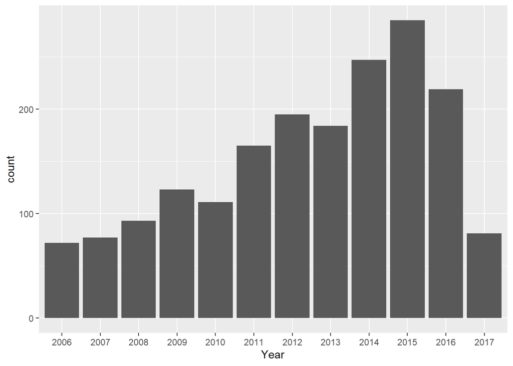

```r
ggplot(choco, aes(x = as.factor(Review.Date))) +
  geom_bar() + xlab("Year")
```

It appears to trend upwards, but drops off in the last 2 years.

#Question set II

For each of the questions below provide at least one graphic as a basis for your answer.

1. How are ratings distributed? Draw a histogram of ratings and describe it. Don’t forget to mention outliers, if there are any.

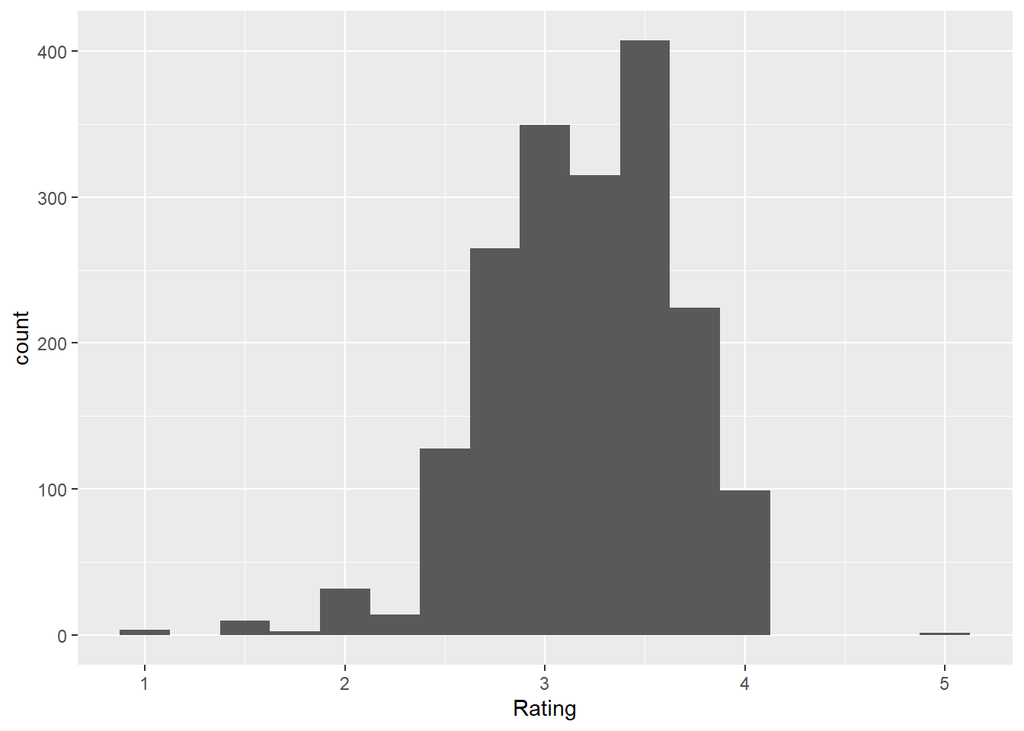

```r
ggplot(choco, aes(x = Rating)) +
  geom_histogram(binwidth = 0.25)
```

The ratings are normally distributed with most of the data lying between 2.5 and 4. There are more outliers in the lower part of the data between 1 - 2.5, but there is at least 1 greater than 4.

2. Do ratings depend on the cocoa percentage of a chocolate bar?

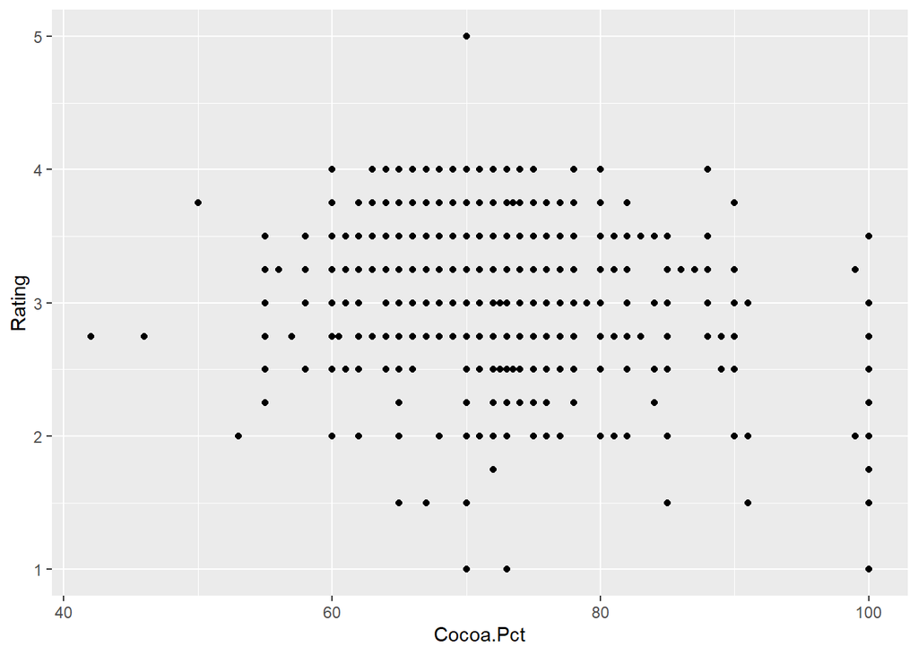

```r
ggplot(choco, aes(x = Cocoa.Pct, y = Rating)) + geom_point()
```

There appears to be no sort of correlation between the percentage of cocoa in the bar and the rating it gets.

3. How do ratings compare across different company locations? Focus on the three locations with the most ratings:

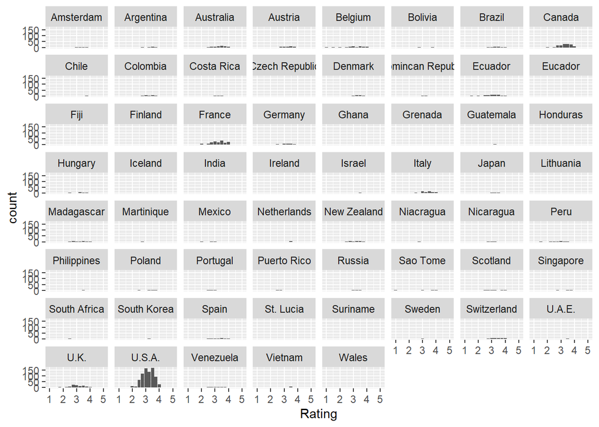

```r
ggplot(choco, aes(x = Rating)) + geom_bar() + facet_wrap(~Company.Location)
```

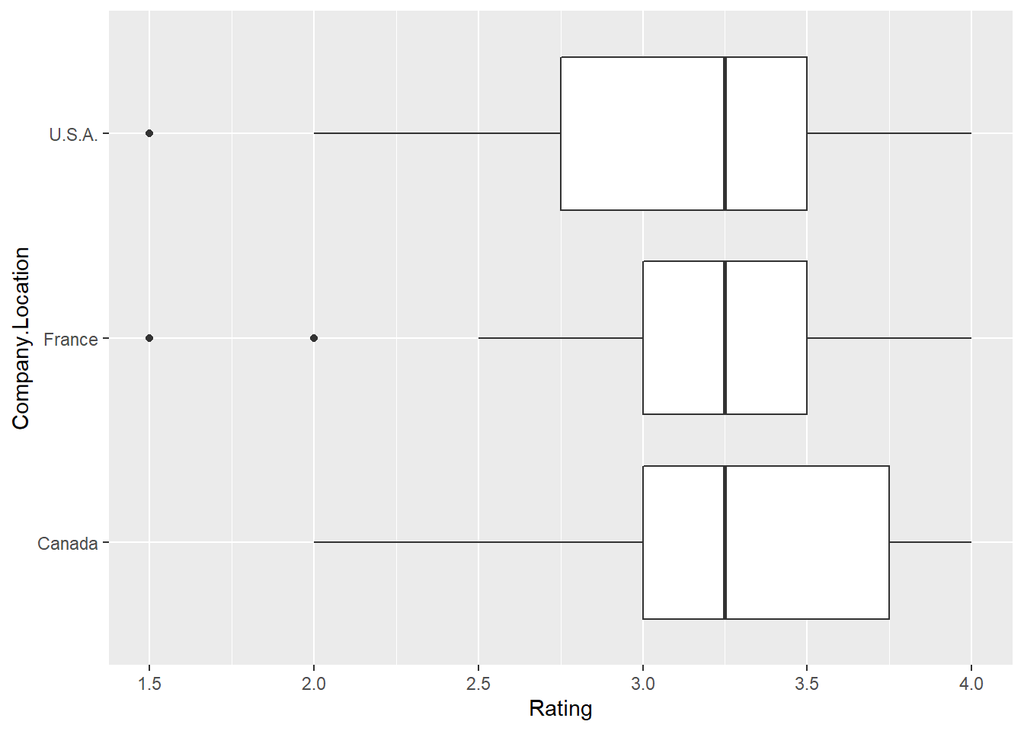

```r
top3 <- dplyr::filter(choco, Company.Location %in% c("U.S.A.", "France", "Canada"))
ggplot(top3, aes(x = Company.Location, y = Rating)) + geom_boxplot() + coord_flip()
```

Despite the fact that the United States has the most bars, it’s ratings are similar to countries such as Canada and France, with similar distributions between them. This implies that there is no correlation between the country and the rating of its bars.

#Own Question

1. Do the type of beans/country of bean origin affect the rating of the bars?

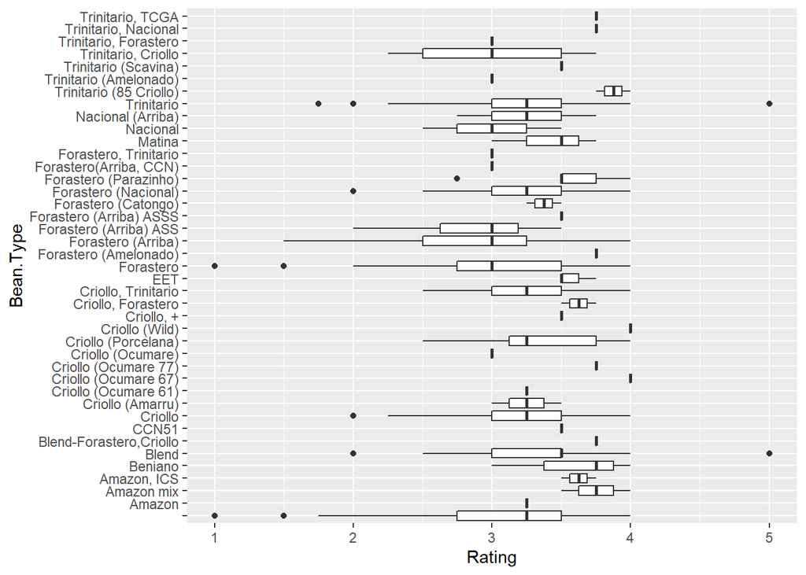

```r
ggplot(choco, aes(x = Bean.Type, y = Rating)) + geom_boxplot() + coord_flip()
```

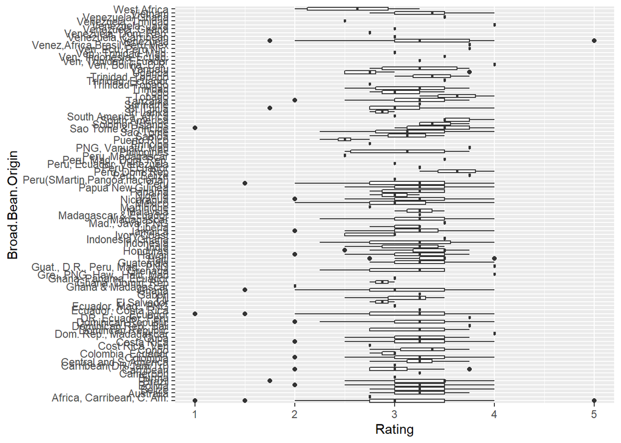

```r
ggplot(choco, aes(x = Broad.Bean.Origin, y = Rating)) + geom_boxplot() + coord_flip()
```

There appears to be no correlation between the bean type or its origin and the rating that the bar gets. Both of the graphs displayed appear to have similar distributions. Therefore, neither the bean type or its origin should be used to determine the quality of a bar.

#Workflow

I began by creating a Github project and importing it into RStudio. Then, I created the RMarkdown file and followed along with the directions, answering the given questions with certain R functions. After completing the question on determining if the company location had any affect on the rating, I decided I wanted to know if the bean’s type or origin had any affect on its rating. The best way to do this was using a boxplot with the rating and the other variable. This way, the number of each did not affect the way I viewed the data. Then I answered my questions based on the data I found.